# Statistical Inference for inter-arrival times of extreme events in bursty time series

Abstract

In many complex systems studied in statistical physics, inter-arrival times between events such as solar flares, trades and neuron voltages follow a heavy-tailed distribution. The set of event times is fractal-like, being dense in some time windows and empty in others, a phenomenon which has been dubbed “bursty”.

This article provides a new model for the threshold inter-exceedance *times*; the threshold exceedances are modeled via the standard Peaks Over Threshold (POT) method. For high thresholds and infinite-mean waiting times, we show that the times between threshold crossings are Mittag-Leffler distributed, and thus form a “fractional Poisson Process” which generalizes the standard Poisson Process of threshold exceedances. We provide graphical means of estimating model parameters and assessing model fit. Along the way, we apply our inference method to a real-world bursty time series, and show how the memory of the Mittag-Leffler distribution affects the predictive distribution for the time until the next extreme event.

# Introduction

Time series displaying temporally inhomogeneous behaviour have received strong interest in the recent statistical physics literature (Barabási 2005; J. Oliveira and Barabási 2005; Vasquez et al. 2006; Vazquez et al. 2007; Omi and Shinomoto 2011; Min, Goh, and Vazquez 2011; Karsai et al. 2011; Bagrow and Brockmann 2013). They have been observed in the context of earthquakes, sunspots, neuronal activity and human communication (see Karsai et al. 2012; Vajna, Tóth, and Kertész 2013; Mark M Meerschaert and Stoev 2008 for a list of references). Such time series exhibit high activity in some ‘bursty’ intervals, which alternate with other, quiet intervals. Although several mechanisms are plausible explanations for bursty behaviour (most prominently self-exciting point process by Hawkes (1971)), there seems to be one salient feature which very typically indicates the departure from temporal homogeneity: a heavy-tailed distribution of waiting times (Vasquez et al. 2006; Karsai et al. 2012; Vajna, Tóth, and Kertész 2013). As we show below in simulations, a simple renewal process with heavy-tailed waiting times can capture this type of dynamics. For many systems, the renewal property is appropriate; a simple test of the absence of correlations in a succession of waiting times can be undertaken by randomly reshuffling the waiting times (Karsai et al. 2012).

Often a magnitude, or mark can be assigned to each event in the renewal process, such as for earthquakes, solar flares or neuron voltages. The Peaks-Over-Threshold model (POT, see e.g. Coles 2001) applies a threshold to the magnitudes, and fits a Generalized Pareto distribution to the threshold exceedances. A commonly made assumption in POT models is that times between events are either fixed or light-tailed, and this entails that the threshold crossing times form a Poisson process (Hsing, Hüsler, and Leadbetter 1988). Then as one increases the threshold and thus decreases the threshold crossing probability $p$, the Poisson process is rarefied, i.e. its intensity decreases *linearly* with $p$ (see e.g. Beirlant et al. 2006).

As will be shown below, in the heavy-tailed waiting time scenario threshold crossing times form a *fractional Poisson process* (Laskin 2003; Mark M Meerschaert, Nane, and Vellaisamy 2011), which is a renewal process with Mittag-Leffler distributed waiting times. The family of Mittag-Leffler distributions nests the exponential distribution (Haubold, Mathai, and Saxena 2011), and hence the fractional Poisson process generalizes the standard Poisson process. Again as the threshold size increases and the threshold crossing probability $p$ decreases, the fractional Poisson process is rarefied: The scale parameter of the Mittag-Leffler inter-arrival times of threshold crossing times increases, but *superlinearly*; see the Theorem below.

Maxima of events which occur according to a renewal process with heavy-tailed waiting times have been studied under the names “Continuous Time Random Maxima process” (CTRM) (Benson, Schumer, and Meerschaert 2007; Mark M Meerschaert and Stoev 2008; Hees and Scheffler 2016; Hees and Scheffler 2017), “Max-Renewal process” (Silvestrov 2002; Silvestrov and Teugels 2004; Basrak and Špoljarić 2015), and “Shock process” (Esary and Marshall 1973; Shanthikumar and Sumita 1983; Shanthikumar and Sumita 1984; Shanthikumar and Sumita 1985; Anderson 1987; Gut and Hüsler 1999). The existing literature focuses on probabilistic results surrounding these models. In this work, however, we introduce a method of inference for this type of model, which is seemingly not available in the literature.

We review the marked renewal process in Section 2, and derive a scaling limit theorem for inter-exceedance times in Section 3. We give a statistical procedure to estimate model parameters via stability plots in Section 5, but to set the stage we first discuss inference for the Mittag-Leffler distribution in Section 4. (A simulation study of the effectiveness of our statistical procedure is given in the appendix.) Diagnostic plots for model criticism are discussed in Section 6. In Section 7, we discuss the memory property of the Mittag-Leffler distribution, and how it affects the predictive distribution for the time until the next threshold crossing event. Section 8 concludes. For all statistical computations we have used R (R Core Team 2018). All code and data used for the analysis in this article has been organized into an R package `CTRE` (https://github.com/UNSW-MATH/CTRE). The source code for the figures generated in this manuscript is available online at https://github.com/UNSW-MATH/bursty-POT.

# Continuous Time Random Exceedances (CTRE)

As a model for extreme observations, we use a Marked Renewal Process (MRP):

**Definition (MRP):**

Let $(W,J), (W_1, J_1), (W_2, J_2), \ldots$ be i.i.d. pairs of random variables, where the $W_k > 0$ are interpreted as the *waiting times* and $J_k \in [x_L, x_R]$ as the *event magnitudes* ($x_L \in [-\infty, +\infty), x_R \in (-\infty, +\infty]$). If $W$ and $J$ are independent, the Marked Renewal Process is said to be *uncoupled*.

Note that the $k$-th magnitude $J_k$ occurs at time $T_k = W_1 + \ldots + W_k$. Based on an MRP, we define the Continuous Time Random Exceedance model (CTRE) as follows:

**Definition (CTRE):**

Given a threshold $\ell \in (x_L, x_R)$, consider the stopping time
$$\tau(\ell) := \min\{k: J_k > \ell\},\quad \ell \in (x_L, x_R).$$
Define the pair of random variables $(X(\ell), T(\ell))$ via
$$X(\ell) = J_{\tau(\ell)} - \ell, \quad
T(\ell) = \sum_{k=1}^{\tau(\ell)} W_k.$$
By restarting the MRP at $\tau(\ell)$, inductively define the two i.i.d. sequences $T(\ell,n)$ and $X(\ell, n)$, $n \in \mathbb N$, called the “interarrival times” and the “exceedances”, respectively. The pair sequence $(T(\ell, n), W(\ell, n))_{n \in \mathbb N}$ is called a Continuous Time Random Exceedance model (CTRE). If the underlying MRP is uncoupled, then the CTRE is also called uncoupled.

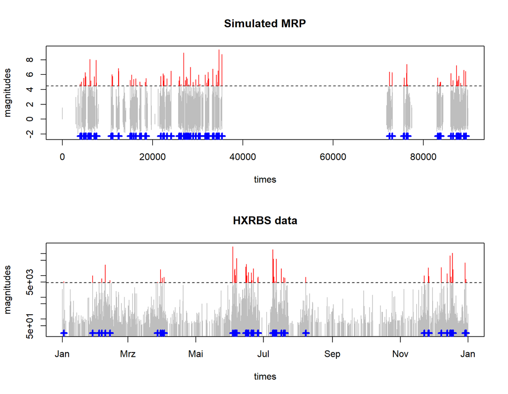

Exceedances (red) and Times until Exceedance (durations between blue crosses) for a given threshold $\ell$ (dashed line).

In this article, we restrict ourselves to the uncoupled case, where the two sequences $X(\ell, n)_{n \in \mathbb N}$ and $T(\ell, n)_{n \in \mathbb N}$ are independent.[^1] Figure shows a simulated dataset in the top panel, where $W$ has a stable distribution with tail parameter $\beta =$ 0.8 (and skewness $1$ and location $0$), and where $J$ is from a standard Gumbel distribution. In the bottom panel, we plot a time series of solar flare intensities derived from a NASA dataset (Dennis et al. 1991)[^2]. Clearly, the simulated data exhibit long intervals *without any* events, whereas in the real-world dataset events appear continuously. The threshold exceedances, however, appear to have similar statistical behaviour in both models. Observations below a threshold are commonly discarded in Extreme Value Theory (POT approach); likewise, the CTRE model interprets these observations as noise and filters them out.

# Scaling limit of Exceedance Times

In this section we state and prove the key theorem, see below. For an accessible introduction to regular variation and stable limit theorems, we recommend the book by Mark M Meerschaert and Sikorskii (2012).

**Theorem:**

for a function $b(n)$ which is regularly varying at $\infty$ with parameter $1/\beta$, and where $\mathbf E[\exp(-sD)] = \exp(-s^\beta)$. Write $p := \mathbf P(J > \ell)$. Then the weak convergence
$$\frac{T(\ell)} {b(1/p)} \to W_\beta \quad \text{ as } \quad \ell \uparrow x_R$$
holds, where the Mittag-Leffler random variable $W_\beta$ is defined on the positive real numbers via
$$\mathbf E[\exp(-sW_\beta)] = \frac{1}{1+s^\beta}.$$

For a scale parameter $\sigma > 0$, we write ${\rm ML}(\beta, \sigma)$ for the distribution of $\sigma W_\beta$. The Mittag-Leffler distribution with parameter $\beta \in (0,1]$ is a heavy-tailed positive distribution for $\beta < 1$, with infinite mean. However, as $\beta \uparrow 1$, ${\rm ML}(\beta, \sigma)$ converges weakly to the exponential distribution ${\rm Exp}(\sigma)$. This means that although its moments are all infinite, the Mittag-Leffler distribution may (if $\beta$ is close to 1) be indistinguishable from the exponential distribution, for the purposes of applied statistics. For a detailed reference on the Mittag-Leffler distribution, see e.g. Haubold, Mathai, and Saxena (2011), and for algorithms, see e.g. the R package `MittagLeffleR` (Gill and Straka 2017).

#### *Proof of Theorem:*

We interpret the threshold crossing time $T(\ell)$ as the hitting time of the underlying CTRM (Continuous Time Random Maxima) or “max-renewal process”, and then utilize a result by Mark M Meerschaert and Stoev (2008). The running maximum process is defined as
$$M(c) := J_1 \vee \ldots \vee J_{\lfloor c \rfloor},$$
and since we assume that the $J_k$ have a continuous distribution, there exist norming functions $a(c)$ and $d(c)$ such that
$$\mathbf P\left[ \frac{M(c) - d(c)}{a(c)} \le \ell^* \right]
\longrightarrow F(\ell^*), \quad t \to \infty$$
where $F$ is a generalized extreme value distribution, and $\ell^*$ is any value from the support of $F$. The CTRM process is then defined via
$$V(t) = M(N(t)), \quad t \ge 0$$
where $N(t)$ is the renewal process associated with the waiting times $W_k$:
$$N(t) = \max\{n: W_1 + \ldots + W_n \le t\}.$$
Now a key observation is that
$$T(\ell) = \inf\{t: V(t) > \ell\},$$
and that
$$T(\ell) > t \quad \text{ if and only if } \quad V(t) \le \ell.$$
By (Theorem 3.1, Mark M Meerschaert and Stoev 2008), we have the stochastic process convergence
$$\frac{V(ct) - d(\tilde b(c))}{a(\tilde b(c))}
\stackrel{d}{\longrightarrow} Y(t), \quad t > 0.$$
where $Y(t)$ is a time-changed (“subordinated”) extremal process, and where $\tilde b(c)$ is a regularly varying norming function which is *inverse* to $b(c)$, in the sense that $b(\tilde b(c)) \sim c \sim \tilde b(b(c))$.

Without loss of generality, we choose $\ell^*$ such that $F(\ell^*) = 1/e$, and let $\ell = a(\tilde b(c)) \ell^* + d(\tilde b(c))$. We may then calculate
$$\mathbf P\left[ \frac{T(\ell)}{b(1/p)} > t \right]
= \mathbf P[T(\ell) > b(1/p) t]
= \mathbf P[V(ct) \le \ell]$$
where we have substituted $c = b(1/p)$. Moreover
$$\mathbf P[V(ct) \le \ell]
= \mathbf P\left[ \frac{V(ct) - d(\tilde b(c))}{a(\tilde b(c))}
\le \frac{\ell - d(\tilde b(c))}{a(\tilde b(c))} \right]
\longrightarrow \mathbf P\left[ Y(t) \le \ell^* \right]$$
Defining the hitting time of level $\ell^*$ by $Y(t)$ as $\xi_{\ell^*} := \inf\{t: Y(t) > \ell^*\}$, we then have
$$P\left[ Y(t) \le \ell^* \right] = \mathbf P[\xi_{\ell^*} > t]
= \mathbf P[(-\log F(\ell^*))^{-1/\beta} X^{1/\beta} D > t]$$
by (Proposition 4.2, Mark M Meerschaert and Stoev 2008), where $X$ is an exponential random variable with mean $1$. Using (Theorem 19.1, Haubold, Mathai, and Saxena 2011), we see that $X^{1/\beta} D \sim {\rm ML}(\beta, 1)$, concluding the proof.

**Remark:**

If $\beta = 1$, the result of the Theorem above is standard, see e.g. Equation (2.2) in Gut and Hüsler (1999).

# Model Choice and inference for the Mittag-Leffler distribution

[figure not shown]

MSE for sample sizes n=30, 100, 200 for the tail and scale estimations via log-moments and maximum likelihood estimation

[figure not shown]

Type One error for bootstrapped LRT for different sample sizes

[figure not shown]

# Inference on Exceedance times

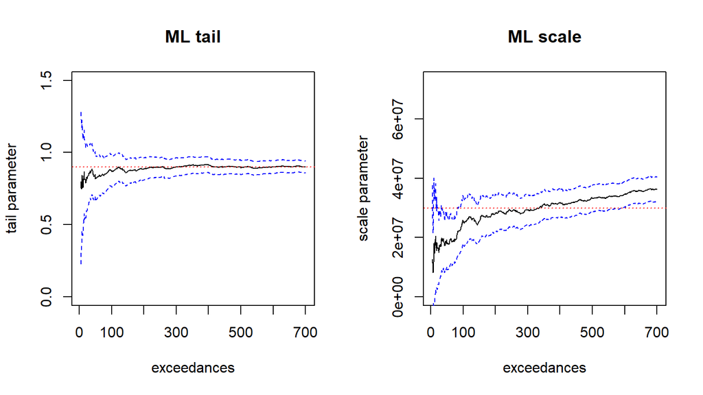

The Theorem in Section implies that for a high threshold $\ell$ we may approximate the distribution of $T(\ell)$ with an ${\rm ML}(\beta, b(1/p))$ distribution, where $b(\,)$ varies regularly at $\infty$ with parameter $1/\beta$. Building on the POT (Peaks Over Threshold) method, we propose the following estimation procedure for the distribution of $T(\ell)$:

1. For a range of thresholds $\ell$ near the largest order statistics, extract datasets of exceedance times $\{T(\ell, i)\}_i$.
2. For each choice of threshold $\ell$, fit a Mittag-Leffler distribution to the resulting dataset $\{T(\ell, i)\}_i$. This results in the estimates $\{\hat\beta(\ell)\}_\ell$ and $\{\hat \sigma(\ell)\}_\ell$.
3. Plot $\ell$ vs. $\hat \beta(\ell)$. As $\ell$ increases towards $x_R$, $\hat \beta(\ell)$ *stabilizes* around a constant $\hat \beta$. Use $\hat \beta$ as an estimate for the tail parameter $\beta$ of the Mittag-Leffler distribution of exceedance times.
4. Approximate $p \approx |\{k: J_k > \ell\}| / n$. Recall that $b(c)$ is regularly varying with parameter $1/\beta$, and hence has the representation $b(c) = L(c) c^{1/\beta}$ for some slowly varying function $L(c)$. Assuming that the variation of $L(c)$ is negligible, we hence plot $\ell$ vs. $p^{1/\hat \beta} \hat \sigma(\ell)$. Again as $\ell$ increases towards $x_R$, $p^{1/\hat \beta} \hat \sigma(\ell)$ is expected to stabilize around a constant $\hat \sigma_0$. We then use $p^{-1/\hat \beta} \hat \sigma_0$ as an estimate of the scale parameter of the Mittag-Leffler distribution of exceedance times for the level $\ell$.

The above approach, though theoretically sound, benefits from the following practical adjustments (compare with Figure ):

- We choose $\ell$ from the order statistics, i.e. $\ell$ is the $k$-th largest of the observations $X_j$, where $k$ runs from $k_\text{min}, k_\text{min} + 1, \ldots, k_\text{max}$. The datasets are then of length $k-1$.
- We use $k$ rather than $\ell$ for the horizontal axis of our plots.
- In Step 4, rather than plotting $p^{1/\hat \beta} \hat \sigma(\ell)$ we plot $k^{1/\hat \beta} \hat \sigma(\ell)$. This changes $\hat \sigma_0$ by the multiplicative constant $n^{1/\hat \beta}$, but has the advantage that $\hat \sigma_0$ does not change if one pre-processes the data by removing all observations below a certain threshold.

The estimates $\hat \beta$ and $\hat \sigma_0$ give an estimate of the distribution of exceedance times, dependent on the threshold $\ell$:
$$\begin{align*}
T(\ell) \sim {\rm ML}(\hat \beta, k^{-1/\hat \beta} \hat \sigma_0).
\end{align*}$$

For quick estimates of the Mittag-Leffler parameters we have used the method of log-transformed moments by Cahoy (2013). We have verified the validity of our estimation algorithm via simulations, see the appendix.

# Checking Model Assumptions

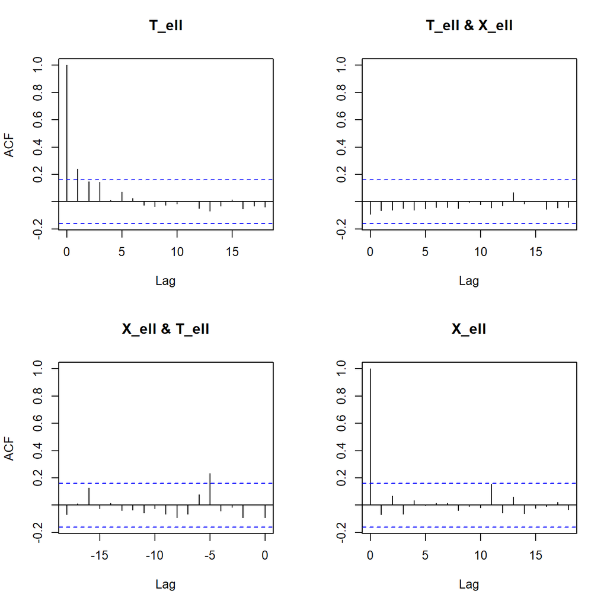

Diagnostic plots for the solar flare data: auto-correlation function.

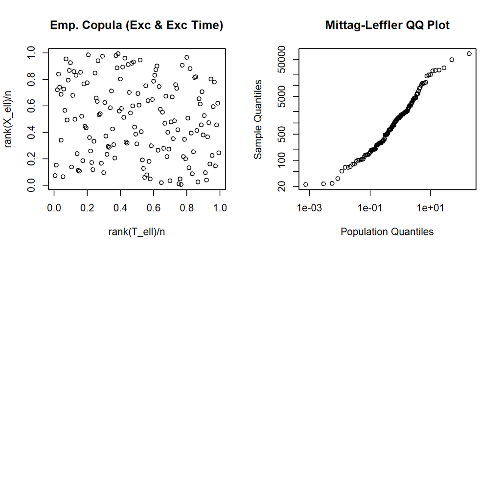

Diagnostic plots for the solar flare data: empirical copula and QQ Plot.

The CTRE model is based on three main assumptions, which are repeated below. For each assumption, we suggest one means of checking if it holds:

**i.i.d.:**

After removing the “noise observations” below the smallest threshold $\ell_0$, the pair sequence $(T(\ell_0, i), X(\ell_0,i))$ is i.i.d. An indication if this is true is given by an auto-correlation plot for the logarithms (to ensure finite moments) of the two time series.

**Uncoupled:**

Each $T(\ell, i)$ is independent of each $X(\ell, i)$. We propose an empirical copula plot to check for any dependence.

**${\rm ML}(\beta, \sigma)$ distribution of $T(\ell, i)$:**

Apply a cutoff at the lowest threshold $\ell_0$, extract the threshold crossing times, and create a QQ Plot for the Mittag-Leffler distribution. Use a log-Moment estimate of the tail parameter for the theoretical / population quantiles of the plot.

# Predicting the time of the next threshold crossing

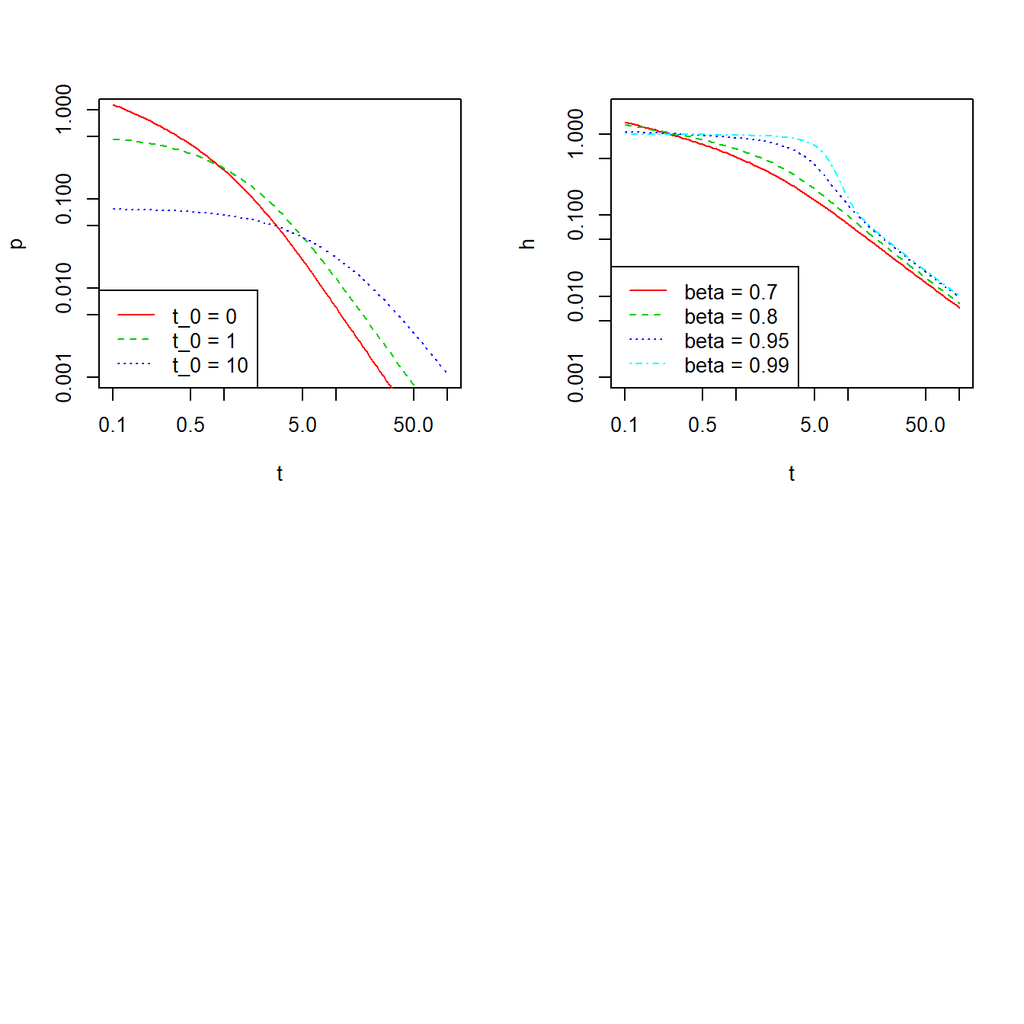

Left: Conditional distribution of time until next threshold crossing, depending on elapsed time $t_0$ since last crossing ($\beta = 0.8$, $\sigma_0 = 1$). Right: Hazard rate depending on tail parameter $\beta$.

It is beyond the scope of the current paper to incorporate parameter uncertainty into our predictive distribution for the next threshold crossing; however, methods as described by Scarrott and Macdonald (2012) and Lee, Fan, and Sisson (2015) are likely to extend to our setting.

# Simulation study

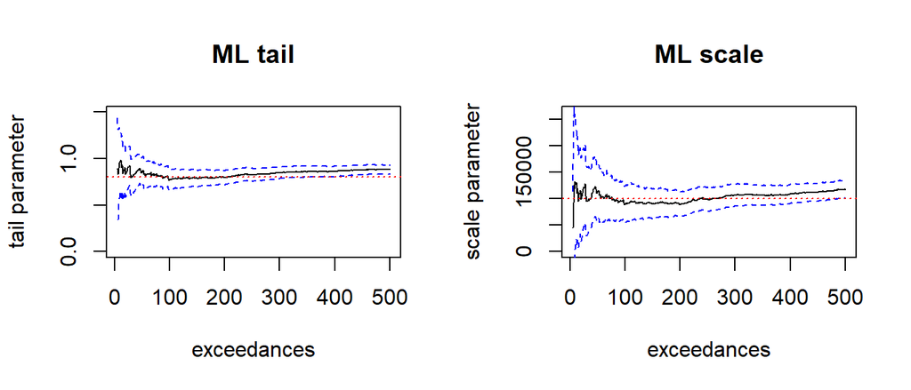

Tail and scale estimates for simulated data, with waiting times drawn from the stable distribution $S_\beta(\cos(\pi \beta/2)^{1/\beta}, +1, 0)$ with $\beta = 0.8$. Dashed lines are 95% confidence intervals, dotted lines are the known theoretical values ($0.8$ and $10000^{1/0.8}$).

# Discussion & Conclusion

When we introduced the CTRE model, we assumed that all events are i.i.d. This assumption is likely sufficient but not necessary for our limit theorem to hold. Moreover, any data below a (minimum) threshold $\ell_0$ is discarded for CTREs, and hence need not satisfy the i.i.d. assumption. For the purposes of statistical inference, we merely require that the inter-threshold-crossing times are i.i.d.

The bursty CTRE approach to model “non-Poissonian” threshold crossing times should be contrasted with the (now standard) approach of clusters of extremes, see e.g. Ferro and Segers (2003). In this approach, i.i.d. event sequences of magnitudes are generalized to stationary sequences of event magnitudes (subject to a mixing condition). The two approaches are fundamentally different: A clustering model assumes that each event belongs to one particular (latent) group of events. For bursts, however, the aim is to identify an underlying scale-free pattern in the event dynamics, which is often characteristic of complex systems. It is an interesting open problem to develop quality criteria, based e.g. on measures of surprise (Lee, Fan, and Sisson 2015), which guide an applied statistician in the choice between a clustering and a CTRE approach for a particular problem. Moreover, we believe it may be possible to unify the two approaches by considering CTREs based on MRPs with a *stationary*, rather than i.i.d., sequence of magnitudes.

Finally, a purely scale-free pattern for event times may be too rigid an assumption for some bursty time series, because often the heavy-tailed character of the inter-arrival time distribution does not hold at all time scales; rather, it applies at short and intermediate time scales, and is truncated (or tempered, reverting to an exponential distribution) at very long time scales (see e.g. Mark M. Meerschaert, Roy, and Shao 2012; and Aban, Meerschaert, and Panorska 2006). In such situations, a “tempered” Mittag-Leffler distribution may provide a more realistic fit, which we aim to introduce in follow-up work.

## Acknowledgements

The authors would like to thank Prof. Peter Scheffler for insights on stochastic process limits for CTRMs, Roloand Fried for discussion according the statistical methods and Gurtek Gill who helped create the MittagLeffleR R-package.

# References

Aban, Inmaculada B, Mark M Meerschaert, and Anna K Panorska. 2006. “Parameter Estimation for the Truncated Pareto Distribution.” *J. Am. Stat. Assoc.* 101 (473): 270–77. doi:10.1198/016214505000000411.

Anderson, Kevin K. 1987. “Limit Theorems for General Shock Models with Infinite Mean Intershock Times.” *J. Appl. Probab.* 24 (2): 449–56. http://www.jstor.org/stable/3214268.

Bagrow, James P., and Dirk Brockmann. 2013. “Natural emergence of clusters and bursts in network evolution.” *Phys. Rev. X* 3 (2): 1–6. doi:10.1103/PhysRevX.3.021016.

Barabási, Albert László. 2005. “The origin of bursts and heavy tails in human dynamics.” *Nature* 435 (May): 207–11. doi:10.1038/nature03459.

Basrak, Bojan, and Drago Špoljarić. 2015. “Extremes of random variables observed in renewal times.” *Stat. Probab. Lett.* 97. Elsevier B.V.: 216–21. doi:10.1016/j.spl.2014.11.025.

Beirlant, Jan, Yuri Goegebeur, Johan Segers, and Jozef Teugels. 2006. *Statistics of extremes: theory and applications*. John Wiley & Sons.

Benson, David A, Rina Schumer, and Mark M Meerschaert. 2007. “Recurrence of extreme events with power-law interarrival times.” *Geophys. Res. Lett.* 34 (l16404): DOI:10.1029/2007GL030767. doi:10.1029/2007GL030767.

Cahoy, Dexter O. 2013. “Estimation of Mittag-Leffler Parameters.” *Commun. Stat. - Simul. Comput.* 42 (2): 303–15. doi:10.1080/03610918.2011.640094.

Cahoy, Dexter O, Vladimir V. Uchaikin, and W. A. Woyczynski Wojbor. 2010. “Parameter estimation for fractional Poisson processes.” *J. Stat. Plan. Inference* 140 (11). Elsevier: 3106–20. doi:10.1016/j.jspi.2010.04.016.

Coles, S. 2001. *An Introduction to Statistical Modelling of Extreme Values*. London: Springer-Verlag.

Dennis, Brian R, L E Orwig, G S Kennard, G J Labow, R A Schwartz, A R Shaver, and A K Tolbert. 1991. “The complete Hard X Ray Burst Spectrometer event list, 1980-1989.” https://umbra.nascom.nasa.gov/smm/hxrbs.html.

Esary, J. D., and A. W. Marshall. 1973. “Shock Models and Wear Processes.” doi:10.1214/aop/1176996891.

Ferro, Christopher AT, and Johan Segers. 2003. “Inference for Clusters of Extreme Values.” *Journal of the Royal Statistical Society: Series B (Statistical Methodology)* 65 (2). Wiley Online Library: 545–56.

Gill, Gurtek, and Peter Straka. 2017. *MittagLeffleR: Using the Mittag-Leffler Distributions in R*. https://strakaps.github.io/MittagLeffleR/.

Gut, Allan, and Jürg Hüsler. 1999. “Extreme Shock Models.” *Extremes*, no. 1983: 295–307. http://link.springer.com/article/10.1023/A:1009959004020.

Haubold, H.J., A. M. Mathai, and R. K. Saxena. 2011. “Mittag-Leffler Functions and Their Applications.” *J. Appl. Math.* 2011: 1–51. doi:10.1155/2011/298628.

Hawkes, Alan G. 1971. “Point spectra of some mutually exciting point processes.” *J. R. Stat. Soc. Ser. B Stat. Methodol.* JSTOR, 438–43.

Hees, Katharina, and Hans-Peter Scheffler. 2016. “On joint sum/max stability and sum/max domains of attraction,” June, 1–31. http://arxiv.org/abs/1606.03109.

———. 2017. “Coupled Continuous Time Random Maxima.” *Extremes*, no. June (September). Extremes: 1–24. doi:10.1007/s10687-017-0304-6.

Hsing, T, J Hüsler, and M R Leadbetter. 1988. “On the Exceedance Point Process for a Stationary Sequence” 78: 97–112.

Karsai, Márton, Kimmo Kaski, Albert László Barabási, and János Kertész. 2012. “Universal features of correlated bursty behaviour.” *Sci. Rep.* 2. doi:10.1038/srep00397.

Karsai, Márton, M. Kivelä, R. K. Pan, K. Kaski, J. Kertész, Albert László Barabási, and J. Saramäki. 2011. “Small but slow world: How network topology and burstiness slow down spreading.” *Phys. Rev. E - Stat. Nonlinear, Soft Matter Phys.* 83: 1–4. doi:10.1103/PhysRevE.83.025102.

Kozubowski, Tomasz J. 2001. “Fractional Moment Estimation of Linnik and Mittag-Leffler Parameters.” *Mathematical and Computer Modelling* 34 (9-11). Elsevier: 1023–35.

Laskin, Nick. 2003. “Fractional Poisson process.” *Commun. Nonlinear Sci. Numer. Simul.* 8 (3-4): 201–13. doi:10.1016/S1007-5704(03)00037-6.

Lee, J., Y. Fan, and S. A. Sisson. 2015. “Bayesian threshold selection for extremal models using measures of surprise.” *Comput. Stat. Data Anal.* 85. Elsevier B.V.: 84–99. doi:10.1016/j.csda.2014.12.004.

Meerschaert, Mark M, and Alla Sikorskii. 2012. *Stochastic Models for Fractional Calculus*. Vol. 43. Walter de Gruyter.

Meerschaert, Mark M, and Stilian A Stoev. 2008. “Extremal limit theorems for observations separated by random power law waiting times.” *J. Stat. Plan. Inference* 139 (7): 2175–88. doi:10.1016/j.jspi.2008.10.005.

Meerschaert, Mark M, Erkan Nane, and P. Vellaisamy. 2011. “The fractional Poisson process and the inverse stable subordinator.” *Electron. J. Probab.* 16: 1600–1620. doi:10.1214/EJP.v16-920.

Meerschaert, Mark M., Parthanil Roy, and Qin Shao. 2012. “Parameter estimation for exponentially tempered power law distributions.” *Commun. Stat. - Theory Methods* 41 (10): 1839–56. doi:10.1080/03610926.2011.552828.

Min, Byungjoon, K. I. Goh, and Alexei Vazquez. 2011. “Spreading dynamics following bursty human activity patterns.” *Phys. Rev. E - Stat. Nonlinear, Soft Matter Phys.* 83 (3): 2–5. doi:10.1103/PhysRevE.83.036102.

Oliveira, J, and Albert László Barabási. 2005. “Darwin and Einstein correspondence patterns.” *Nature* 437 (October): 1251. doi:10.0138/4371251a.

Omi, Takahiro, and Shigeru Shinomoto. 2011. “Optimizing Time Histograms for Non-Poissonian Spike Trains.” *Neural Comput.* 23 (12): 3125–44. doi:10.1162/NECO_a_00213.

R Core Team. 2018. *R: A Language and Environment for Statistical Computing*. Vienna, Austria: R Foundation for Statistical Computing. https://www.R-project.org/.

Samorodnitsky, Gennady, and Murad S Taqqu. 1994. *Stable Non-Gaussian Random Processes: Stochastic Models with Infinite Variance*. Stochastic Modeling. London: Chapman Hall.

Scarrott, Carl, and Anna Macdonald. 2012. “A REVIEW OF EXTREME VALUE THRESHOLD ESTIMATION AND UNCERTAINTY QUANTIFICATION.” *REVSTAT – Stat. J.* 10 (1): 33–60.

Shanthikumar, J. George, and Ushio Sumita. 1983. “General shock models associated with correlated renewal sequences.” *J. Appl. Probab.* 20 (3): 600–614. http://www.jstor.org/stable/3213896.

———. 1984. “Distribution Properties of the System Failure Time in a General Shock Model.” *Adv. Appl. Probab.* 16 (2): 363–77. http://www.jstor.org/stable/1427074.

———. 1985. “A class of correlated cumulative shock models.” *Adv. Appl. Probab.* 17 (2): 347–66. http://www.jstor.org/stable/1427145.

Silvestrov, Dmitrii S. 2002. *Limit Theorems for Randomly Stopped Stochastic Processes*. Springer (Berlin, Heidelberg).

Silvestrov, Dmitrii S, and Jozef L. Teugels. 2004. “Limit theorems for mixed max-sum processes with renewal stopping.” *Ann. Appl. Probab.* 14 (4): 1838–68. doi:10.1214/105051604000000215.

Vajna, Szabolcs, Bálint Tóth, and János Kertész. 2013. “Modelling bursty time series.” *New J. Phys.* 15 (10): 103023. doi:10.1088/1367-2630/15/10/103023.

Vasquez, a, J G Oliveira, Z Dezso, K-I Goh, I Kondor, and Albert László Barabási. 2006. “Modeling bursts and heavy tails in human dynamics.” *Phys. Rev. E* 73: 361271–3612718.

Vazquez, Alexei, Balázs Rácz, András Lukács, and Albert László Barabási. 2007. “Impact of non-poissonian activity patterns on spreading processes.” *Phys. Rev. Lett.* 98 (APRIL): 1–4. doi:10.1103/PhysRevLett.98.158702.

Wuertz, Diethelm, Martin Maechler, and Rmetrics core team members. 2016. *Stabledist: Stable Distribution Functions*. https://CRAN.R-project.org/package=stabledist.

[^1]: To see why, note that $X(\ell)$ is, in distribution, simply equal to $J | J > \ell$, independent of any waiting time $W_k$.
[^2]: The “complete Hard X Ray Burst Spectrometer event list” is a comprehensive reference for all measurements of the Hard X Ray Burst Spectrometer on NASA’s Solar Maximum Mission from the time of launch on Feb 14, 1980 to the end of the mission in Dec 1989. 12,776 events were detected, with the “vast majority being solar flares”. The list includes the start time, peak time, duration, and peak rate of each event. We have used “start time” as the variable for event times, and “peak rate” as the variable for event magnitudes.